# Caderno_Inferencia_Estatistica

2024-04-06

# Sumario

# Aula

## Subtitulo

### Silde

# Instrumentação Matemática para Estatística – Prof Wagner Hugo Bonat – 09/03/2024

- Matemática (5 partes)
- Probabilidade (1 parte)
- Inferência (3 partes)

### Tópicos em matemática customizados para DS:

- Fornecer base matemática para entender e criar técnicas de análise de dados
- Visão geral e intuitiva
- Focar nos resultados e suas aplicações
- Não ser exaustivo em cada tópico ou matematicamente (muito) rigoroso
- Suporte computacional para compreender conceitos matemáticos abstratos
- Formar uma base sólida para entender técnicas avançadas:
- Modelagem estatística
- Machine learnig

### O curso não é de receitas, é de fundamentos

- Os objetivos desta abordagem são:
  - Desmestificar o processo peos quais os algoritmos resolvem problemas
  - Mostrar que apesar de existir um conjunto enrme de técnicas, muitas delas são pequenas melhorias em técnicas já existentes
- Promover um uso qualificado das ferramentas já disponíveis

## Referencias:

- Deep Learning, Ian Goodfellow and Yoshua Bengio and Aaro Courville, MIT Press, 2016.
- Mathematics for Machine Learning, Marc Peter Deisenroth, A. Aldo Faisal and Cheng Soon Ong, Cambridge, 2019
- Livro do prof: Matemática para Ciências de Dados

## O que precisamos saber?

- Cálculo Diferencial e Integral
- Funções, limites e continuidade
- Derivadas
- Integrais
- Álgebra Matricial
- Vetores e escalares
- Matrizes
- Sistemas de equações lineares
- Decomposições matriciais
- Métodos Numéricos
- Sistemas de equações não-lineares
- Diferenciação e integração numérica
- Otimização

## Exemplos motivacionais:

### Classificador binário

Ferramenta popular em modelagem estatística e aprendizagem de maquina

Objetivo: classificar um individuo ou observação em uma entre duas categorias

Exemplos:

- Classificar um paciente como sadio ou doente
- Classificar um cliente como bom ou mal pagador etc

## Diversos algoritmos disponíveis:

- Arvores de classificação
- Máquinas de vetores de suporte
- Redes neurais
- Gradient boost
- Regressão logística é muito popular

## Descrição matemática:

- Suponha que temos um conjunto de dados $y_{i}$ para $i=1,…,n$ .
- Cada $y_{i} \in [0,1]$ (é zero ou 1) -> sim ou não, saudável ou doente etc

Potenciais objetivos:

- Descrever o relacionamento de $y_{i}$ com um conjunto de variáveis explanatórios $x_{ij}$ com $j=1,…,p$
- Classificar uma nova observação como 0 ou 1

Exemplo - Conjunto de dados com 3 colunas:

- Renda anual do usuário
- Anos de experiencia do usuário
- Se é premium ou não

Objetivos:

- Identificar como as covariáveis renda e anos influenciem a compra premium
- Predizer se um novo usuário será ou não premium
- Orientar campanha de marketing

```r
dados_reg_log <- read.table("./Data_Files/reg_log.txt", header = TRUE)

head(dados_reg_log,n =10)
```

```
##    Premium    Renda Anos
## 1        0 18.90256    4
## 2        1 38.66267    7
## 3        1 82.16108    4
## 4        1 22.34817    8
## 5        1 36.13398    9
## 6        0 52.61761    2
## 7        1 55.36645    5
## 8        1 30.78107    8
## 9        0 21.95257    5
## 10       0 53.84225    5
```

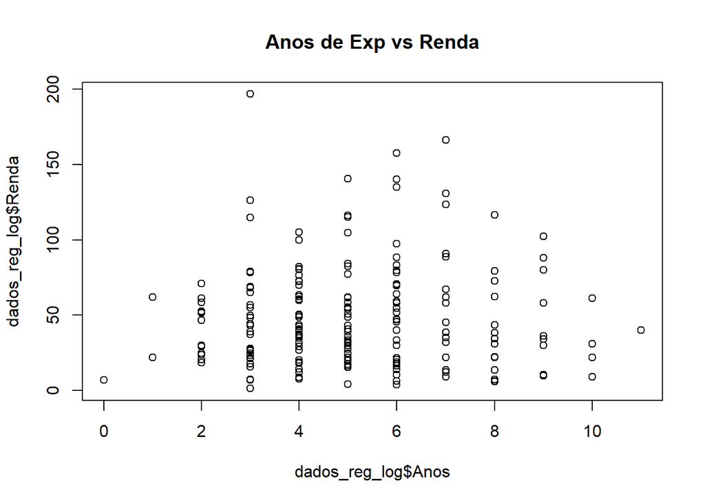

```r
plot(dados_reg_log$Anos, dados_reg_log$Renda, main = "Anos de Exp vs Renda")
```

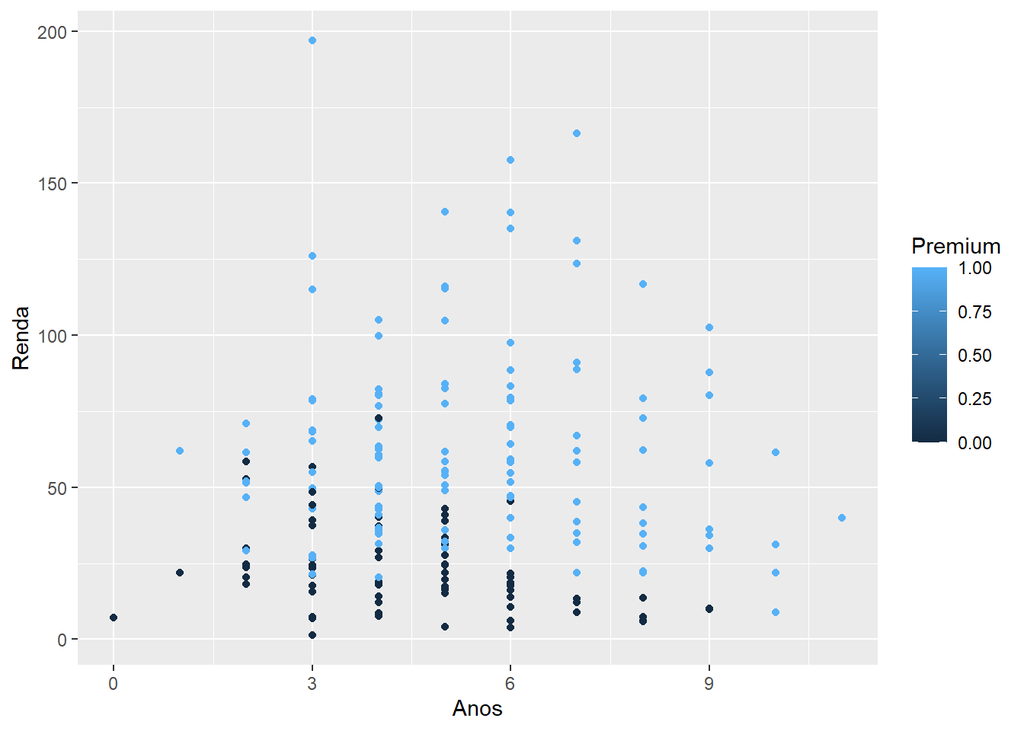

```r
library(ggplot2)
grafico <- ggplot(dados_reg_log,aes(x = Anos, y = Renda, colour = Premium)) + geom_point()

grafico
```

$y_{i} = f (x_{ij})$ $y_{i} = f(x_{ij})+erro$ $erro = y_{i}-f (x_{ij} )$

Construção do classificador:

- Explicar o modelo que descreve a relação entre $y_{i}$ e $x_{ij}$ (i linha-usuário, j coluna-covariável)

$y=f(renda,xp)$, ou seja, y é função dependente de renda e xp

- Especificar função perda (medida de erro)

$erro=g( y_{i},f(x_{ij}))$ função g

```r
f_logit <- function(par, y, renda, anos){
  mu <- 1/(1+exp(-(par[1] + par[2]*renda + par[3]*anos)))
  SQ_logit <- sum((y - mu)^2)
  return(SQ_logit)
}


#f_logit()
```

- Características satisfaça duas equações de distância: $d(y,\mu)>0 | y= \mu$ e $d(y,\mu)=0 | \mu=f(x_{ij})$

Otimizar a função perda:

- Qual algoritmo escolher?
- Como implementá-la?
- Analisar o modelo ajustando

## Kmeans

Clusterização usando kmeans

- Agrupar indivíduos semelhantes
- Individuos no mesmo grupo sejam mais parecidos do que indivíduos em grupos diferentes
- Distância da media